# rsibal_PeerCommentary_baroth_03

Brooke Rothamer

2023-10-25

# Part 1

Write a simple R function, Z.prop.test(), that can perform one- or two-sample Z-tests for **proportion data**, using the following guidelines:

- Your function should take the following arguments: p1 and n1 (no default) representing the estimated proportion and sample size (i.e., based on your sample data); p2 and n2 (both defaulting to NULL) that contain a second sample’s proportion and sample size data in the event of a two-sample test; p0 (no default) as the expected value for the population proportion; and alternative (default “two.sided”) and conf.level (default 0.95), to be used in the same way as in the function t.test().
- When conducting a two-sample test, it should be p1 that is tested as being smaller or larger than p2 when alternative=“less” or alternative=“greater”, the same as in the use of x and y in the function t.test().
- The function should perform a one-sample Z-test using p1, n1, and p0 if either p2 or n2 (or both) is NULL.
- The function should contain a check for the rules of thumb we have talked about (n∗p>5 and n∗(1−p)>5) to ensure the validity of assuming the normal distribution in both the one- and two-sample settings. If this is violated, the function should still complete but it should also print an appropriate warning message.
- The function should return a list containing the members Z (the test statistic), P (the appropriate p value), and CI (the two-sided CI with respect to “conf.level” around p1 in the case of a one-sample test and around p2-p1 in the case of a two-sample test). For all test alternatives (“two.sided”, “greater”, “less”), calculate symmetric CIs based on quantiles of the normal distribution rather than worrying about calculating single-limit confidence bounds.

*Ritika’s Comments: I think we did this function super similarly, with just different placement of the code chunks. I think logic-wise this all looked correct (or at least what I think is correct) to me! One thing I did notice is that for your warning printing you may want to use <= 5 instead of < 5 since the rule is if n x p is not greater than 5 so the warning should print when n x p is equal to 5 or less. Also I ended up doing n1 x p0 instead of n1 x p1 since I thought p referred to the expected proportion but I am not 100% this is right. Otherwise, amazing job Brooke! This was pretty easy for me to follow* ## Z.prop.test

```r
Z.prop.test <- function(p1, n1, p2=NULL, n2=NULL, p0, alternative = "two.sided", conf.level=0.95) {

      if (is.null(p2)|is.null(n2)) {
        #One Sample: this option will only run if p2 or n2 (or both) are NULL
            Z <- (p1 - p0)/(sqrt(p0*(1 - p0)/n1))
          if (alternative == "less") { #This option will run a one-tailed test to see if p1 is less than p2
          P <- pnorm(Z, lower.tail = TRUE)
          }
          if (alternative == "greater") { #This option will run a one-tailed test to see if p1 is greater than p2
          P <- pnorm(Z, lower.tail = FALSE)
          }
          if (alternative == "two.sided") { #This option will run a two-tailed test (default) to see if p1 differs from p2
            if (Z > 0) #if Z is greater than 0, we need to look at the probability above the Z score
                {
                  P <- 2 * pnorm(Z, lower.tail = FALSE) #multiple by 2 to account for probability of being above or below the expected proportion
                }
            if (Z < 0) #if Z is greater than 0, we need to look at the probability up to (below) the Z score
                {
                  P <- 2 * pnorm(Z, lower.tail = TRUE) #times 2 because its 2-tailed
                }
            }
          lower <- p1 - qnorm(1-((1-conf.level)/2)) * sqrt(p1 * (1 - p1)/n1) #1-((1-conf.level)/2) because half the confidence interval is above
          upper <- p1 + qnorm(1-((1-conf.level)/2)) * sqrt(p1 * (1 - p1)/n1) #and half is below
          CI <- c(lower, upper)
          CI
          if (n1*p0 < 5 | n1*(1-p0) < 5)
            {print("Warning: Test may violate the assumptions of the normal distribution. n is not sufficiently large or p0 is close to 1 or 0.")}
          #prints a warning message is the assumptions of a normal distribution are not met
        }

      else{
        # Two Sample: this option will run if p2 and n2 are provided
          ppool <- ((p1+p2)/(n1+n2)) #calculate pooled proportion of the two samples for use in calculating z score
          Z <- (p2 - p1 - p0)/sqrt(ppool*(1-ppool)*((1/n1)+(1/n2)))

          if (alternative == "less") { #This option will run a one-tailed test to see if p2-p1 is less than 0
            P <- pnorm(z, lower.tail = TRUE)
          }

          if (alternative == "greater") { #This option will run a one-tailed test to see if p2-p1 is greater than 0
            P <- pnorm(Z, lower.tail = FALSE)
          }

          if (alternative == "two.sided") { #This option will run a two-tailed test (default) to see if p2-p1 differs from 0
            P <- 1 - pnorm(Z, lower.tail = TRUE) + pnorm(Z, lower.tail = FALSE)
          }
          lower <- (p2-p1) - qnorm(1-((1-conf.level)/2)) * sqrt((p1*(1-p1)/n1) + (p2*(1-p2)/n2)) #I am not entirely sure I calculated SE correctly for a two sample test
          upper <- (p2-p1) + qnorm(1-((1-conf.level)/2)) * sqrt((p1*(1-p1)/n1) + (p2*(1-p2)/n2))
          CI <- c(lower, upper)
          CI
          if (n1*p1 < 5 | n1*(1-p1) < 5 | n2*p2 < 5 | n2*(1-p2) < 5)
            {print("Warning: Test may violate the assumptions of the normal distribution. n is not sufficiently large or p is close to 1 or 0.")}
          #I'm not sure I've expressed the rule correctly here
      }

    return_list <- list(Z, P, CI) # make a list of the items the function should return
    names(return_list) <- c("Z statistic", "p-value", "Confidence Interval") # labels items in the output
    return(return_list) #tell the function to return that list
    }
```

*Ritika’s Comments: Great job testing this out! I didn’t think to add my testing code here but I will definitely be doing it now so thank you!*

Does it work on these samples?

```r
#A Single Sample test of the function
Z.prop.test(p1=0.5, n1=36, p0=0.9, alternative = "two.sided", conf.level=0.95)
```

```
## [1] "Warning: Test may violate the assumptions of the normal distribution. n is not sufficiently large or p0 is close to 1 or 0."
```

```
## $`Z statistic`
## [1] -8
##
## $`p-value`
## [1] 1.244192e-15
##
## $`Confidence Interval`
## [1] 0.3366697 0.6633303
```

```r
#A Two Sample test of the function
Z.prop.test(p1=0.75, n1=36, p2=0.8, n2=50, p0=0, alternative = "two.sided", conf.level=0.95)
```

```
## $`Z statistic`
## [1] 1.719451
##
## $`p-value`
## [1] 0.08553228
##
## $`Confidence Interval`
## [1] -0.1297227  0.2297227
```

## Z.prop.test.t (using a t distribution)

An attempt at a version of the same function using t-distributions of Z scores instead of normal distributions so account for small sample size.

*Ritika’s Comments: oh wow! way to go Brooke! I didnt think to try this out but I bet this is really helpful (even to have just practiced doing) for future stats work. Great job!!*

```r
Z.prop.test.t <- function(p1, n1, p2=NULL, n2=NULL, p0, alternative = "two.sided", conf.level=0.95) {

      if (is.null(p2)|is.null(n2)) {
            Z <- (p1 - p0)/(sqrt(p0*(1 - p0)/n1))
          if (alternative == "less") {
          P <- pt(Z, df = n1 - 1, lower.tail = TRUE) #using the t-distribution, pt(), not normal distribution, pnorm(), because its better for small sample sizes
          }
          if (alternative == "greater") {
          P <- pt(Z, df = n1 - 1, lower.tail = FALSE)
          }
          if (alternative == "two.sided") {
            if (Z > 0)
                {
                  P <- 2 * pt(Z, df = n1 - 1, lower.tail = FALSE)
                }
            if (Z < 0)
                {
                  P <- 2 * pt(Z, df = n1 - 1, lower.tail = TRUE)
                }
            }
          lower <- p1 - qt(df = n1-1, 1-((1-conf.level)/2)) * sqrt(p1 * (1 - p1)/n1)
          upper <- p1 + qt(df = n1-1, 1-((1-conf.level)/2)) * sqrt(p1 * (1 - p1)/n1)
          CI <- c(lower, upper)
          CI
          }
      else{
          ppool <- ((p1+p2)/(n1+n2))
          Z <- (p2 - p1 - p0)/sqrt(ppool*(1-ppool)*((1/n1)+(1/n2)))

          if (alternative == "less") {
            P <- pt(Z, df = n1 - 1, lower.tail = TRUE)
          }

          if (alternative == "greater") {
            P <- pt(Z, df = n1 - 1, lower.tail = FALSE)
          }

          if (alternative == "two.sided") {
            P <- 1 - pt(Z, df = n1 - 1, lower.tail = TRUE) + pt(Z, df = n1 - 1, lower.tail = FALSE)
          }
          lower <- (p2-p1) - qt(df = n1-1, 1-((1-conf.level)/2)) * sqrt((p1*(1-p1)/n1) + (p2*(1-p2)/n2))
          upper <- (p2-p1) + qt(df = n1-1, 1-((1-conf.level)/2)) * sqrt((p1*(1-p1)/n1) + (p2*(1-p2)/n2))
          CI <- c(lower, upper)
          CI
      }
    return_list <- list(Z, P, CI)
    names(return_list) <- c("Z statistic", "p-value", "Confidence Interval")
    return(return_list)
    }
```

Does it work on those same samples?

```r
#A Single Sample test of the function
Z.prop.test.t(p1=0.5, n1=36, p0=0.9, alternative = "two.sided", conf.level=0.95)
```

```
## $`Z statistic`
## [1] -8
##
## $`p-value`
## [1] 2.055403e-09
##
## $`Confidence Interval`
## [1] 0.3308243 0.6691757
```

```r
#A Two Sample test of the function
Z.prop.test.t(p1=0.75, n1=36, p2=0.8, n2=50, p0=0, alternative = "two.sided", conf.level=0.95)
```

```
## $`Z statistic`
## [1] 1.719451
##
## $`p-value`
## [1] 0.09436569
##
## $`Confidence Interval`
## [1] -0.1361547  0.2361547
```

Yes it does, and it gives very similar results except the p value given by the t distribution method is higher and the confidence intervals are a little broader than those prouced from the normal distribution method.

# Part 2

The dataset from Kamilar and Cooper has in it a large number of variables related to life history and body size. For this exercise, the end aim is to fit a simple linear regression model to predict longevity (MaxLongevity_m) measured in months from species’ brain size (Brain_Size_Species_Mean) measured in grams. Do the following for both longevity~brain size and log(longevity)~log(brain size):

```r
data <- read.csv("https://raw.githubusercontent.com/fuzzyatelin/fuzzyatelin.github.io/master/AN588_Fall23/KamilarAndCooperData.csv")
head(data)
```

```
##               Scientific_Name          Family          Genus      Species
## 1 Allenopithecus_nigroviridis Cercopithecidae Allenopithecus nigroviridis
## 2         Allocebus_trichotis Cercopithecidae      Allocebus    trichotis
## 3           Alouatta_belzebul        Atelidae       Alouatta     belzebul
## 4             Alouatta_caraya        Atelidae       Alouatta       caraya
## 5            Alouatta_guariba        Atelidae       Alouatta      guariba
## 6           Alouatta_palliata        Atelidae       Alouatta     palliata
##   Brain_Size_Species_Mean Brain_Size_Female_Mean   Brain_size_Ref
## 1                   58.02                  53.70 Isler et al 2008
## 2                      NA                     NA
## 3                   52.84                  51.19 Isler et al 2008
## 4                   52.63                  47.80 Isler et al 2008
## 5                   51.70                  49.08 Isler et al 2008
## 6                   49.88                  48.04 Isler et al 2008
##   Body_mass_male_mean Body_mass_female_mean Mass_Dimorphism
```

[output cut: 62 more lines]

## Regression models and plotting

Fit the regression model and, using {ggplot2}, produce a scatterplot with the fitted line superimposed upon the data. Append the the fitted model equation to your plot (HINT: use the function geom_text()).

*Ritika’s Comments: I like that you have a separate preparation code chunk here. If you wanted, I believe you can load the data frame here and just reference the variables that way instead of assigning them to new variables, but you totally don’t have to!*

```r
library(ggplot2)
longevity <- data$MaxLongevity_m
log_longevity <- log(data$MaxLongevity_m)
brainsize <- data$Brain_Size_Species_Mean
log_brainsize <- log(data$Brain_Size_Species_Mean)
```

### longevity~brain size

*Ritika’s Comments: Beautiful plots! I could not get my text to look this nice but yours look great! Again, I think we did this section super similarly–everything looks great to me!*

```r
model1 <- lm(longevity ~ brainsize, data = data)
summary(model1)
```

```
##
## Call:
## lm(formula = longevity ~ brainsize, data = data)
##
## Residuals:
##     Min      1Q  Median      3Q     Max
## -198.27  -61.92  -17.78   56.16  331.36
##
## Coefficients:
##             Estimate Std. Error t value Pr(>|t|)
## (Intercept) 248.9523    11.1111   22.41   <2e-16 ***
## brainsize     1.2180     0.1101   11.06   <2e-16 ***
## ---
## Signif. codes:  0 '***' 0.001 '**' 0.01 '*' 0.05 '.' 0.1 ' ' 1
##
## Residual standard error: 90.91 on 126 degrees of freedom
##   (85 observations deleted due to missingness)
## Multiple R-squared:  0.4928, Adjusted R-squared:  0.4887
## F-statistic: 122.4 on 1 and 126 DF,  p-value: < 2.2e-16
```

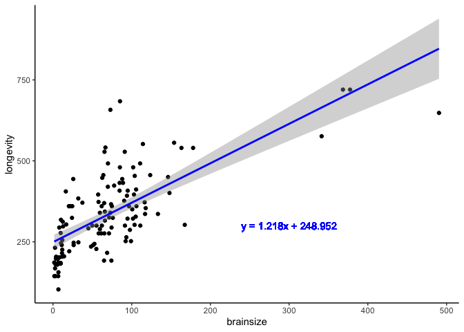

```r
plot1 <- ggplot(data = data, aes(x = brainsize, y = longevity)) +
  geom_point() +
  geom_smooth(method = "lm", formula = y ~ x, color="blue") +
  geom_text(x=300, y=300, label="y = 1.218x + 248.952", color="blue") +
  theme_classic()
plot1
```

### log(longevity)~log(brain size)

```r
model2 <- lm(log_longevity ~ log_brainsize, data = data)
summary(model2)
```

```
##
## Call:
## lm(formula = log_longevity ~ log_brainsize, data = data)
##
## Residuals:
##     Min      1Q  Median      3Q     Max
## -0.6955 -0.1750 -0.0097  0.1788  0.6084
##
## Coefficients:
##               Estimate Std. Error t value Pr(>|t|)
## (Intercept)    4.87895    0.06907   70.63   <2e-16 ***
## log_brainsize  0.23415    0.01781   13.15   <2e-16 ***
## ---
## Signif. codes:  0 '***' 0.001 '**' 0.01 '*' 0.05 '.' 0.1 ' ' 1
##
## Residual standard error: 0.2485 on 126 degrees of freedom
##   (85 observations deleted due to missingness)
## Multiple R-squared:  0.5784, Adjusted R-squared:  0.5751
## F-statistic: 172.9 on 1 and 126 DF,  p-value: < 2.2e-16
```

```r
plot2 <- ggplot(data = data, aes(x = log_brainsize, y = log_longevity)) +
  geom_point() +
  geom_smooth(method = "lm", formula = y ~ x, color="blue") +
  geom_text(x=4, y=5, label="y = 0.2341x + 4.8790", color="blue") +
  theme_classic()
plot2
```

[figure not shown]

## Slope testing

Identify and interpret the point estimate of the slope (β1), as well as the outcome of the test associated with the hypotheses H0: β1 = 0; HA: β1 ≠ 0. Also, find a 90 percent CI for the slope (β1) parameter.

### longevity~brain size

*Ritika’s Comments: I would suggest adding the code you used to get these values here! I think it was the confint() function right? I used the same thing! Great job with your explanations, I definitely did not do that.*

Coefficients: Estimate Std. Error t value Pr(>|t|)  
(Intercept) 248.9523 11.1111 22.41 <2e-16 *brainsize 1.2180 0.1101 11.06 <2e-16*

The slope (β1) of longevity~brain size is 1.218 meaning that for every gram species mean brain size increases, the maximum longevity increases by 1.218 months. The p-value of the test that the slope differs from 0, <2e-16, is less than 0.05, indicates that the slope is not equal to 0.

```r
lower <- 1.2180 - qt(0.95, df = 211) * 0.1101 #213 observations - 2 = 211 df
upper <- 1.2180 + qt(0.95, df = 211) * 0.1101 #1-.9 confidence - .1 divided between the lower and upper calculations
ci <- c(lower, upper)
ci
```

```
## [1] 1.036103 1.399897
```

With 90% confidence, we can say that the actual slope of the relationship is between 1.036103 and 1.399897.

### log(longevity)~log(brain size)

Coefficients (log): Estimate Std. Error t value Pr(>|t|)  
(Intercept) 4.87895 0.06907 70.63 <2e-16 *log_brainsize 0.23415 0.01781 13.15 <2e-16*

```r
lower <- 0.23415 - qt(0.95, df = 211) * 0.01781
upper <- 0.23415 + qt(0.95, df = 211) * 0.01781
ci <- c(lower, upper)
ci
```

```
## [1] 0.204726 0.263574
```

With 90% confidence, we can say that the actual slope of the relationship is between 0.204726 and 0.263574.

## Confidence intervals and prediction intervals

Using your model, add lines for the 90 percent confidence and prediction interval bands on the plot and add a legend to differentiate between the lines.

*Ritika’s Comments: Amazing job! I don’t think I added a prediction band to my graph, just the CI based on the previous step. But this is so much cleaner!!!! You’re graphs turned out very well :)*

### longevity~brain size

```r
ci1 <- predict(model1, newdata = data.frame(brainsize = data$Brain_Size_Species_Mean), interval = "confidence", level = 0.90)  # to calculate confidence intervals for a vector of values

pi1 <- predict(model1, newdata = data.frame(brainsize = data$Brain_Size_Species_Mean), interval = "prediction", level = 0.90)  # to calculate prediction intervals for a vector of values

df1 <- as.data.frame(cbind(brainsize ,longevity, ci1, pi1)) #make a data frame of the x and y values and the newly calculated confidence intervals
names(df1) <- c("brainsize", "longevity", "CIfit", "CIlwr", "CIupr", "PIfit", "PIlwr",
    "PIupr")
head(df1)
```

```
##   brainsize longevity    CIfit    CIlwr    CIupr    PIfit    PIlwr    PIupr
## 1     58.02     276.0 319.6201 306.1354 333.1047 319.6201 168.3750 470.8651
## 2        NA        NA       NA       NA       NA       NA       NA       NA
## 3     52.84        NA 313.3109 299.6449 326.9768 313.3109 162.0496 464.5722
## 4     52.63     243.6 313.0551 299.3805 326.7297 313.0551 161.7930 464.3172
## 5     51.70        NA 311.9224 298.2081 325.6366 311.9224 160.6567 463.1880
## 6     49.88     300.0 309.7056 295.9081 323.5032 309.7056 158.4324 460.9789
```

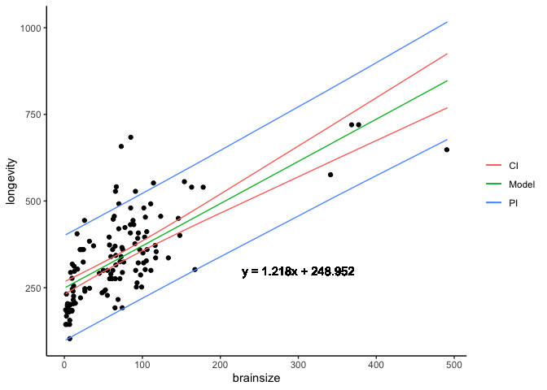

```r
plot1 <- ggplot(data = df1, aes(x = brainsize, y = longevity)) +
  geom_point() +
  geom_text(x=300, y=300, label="y = 1.218x + 248.952") +
  theme_classic() +
  geom_line(aes(x = brainsize, y = CIfit, color="Model")) +
  geom_line(aes(x = brainsize, y = CIlwr, color="CI")) +
  geom_line(aes(x = brainsize, y = CIupr, color="CI")) +
  geom_line(aes(x = brainsize, y = PIlwr, color="PI")) +
  geom_line(aes(x = brainsize, y = PIupr, color="PI")) +
  theme(legend.title=element_blank())
plot1
```

### log(longevity)~log(brain size)

```r
ci2 <- predict(model2, newdata = data.frame(log_longevity = log(data$MaxLongevity_m)), interval = "confidence", level = 0.90)  # to calculate confidence intervals for a vector of values
pi2 <- predict(model2, newdata = data.frame(log_brainsize = log(data$Brain_Size_Species_Mean)), interval = "prediction", level = 0.90)  # to calculate prediction intervals for a vector of values

df2 <- as.data.frame(cbind(log_brainsize, log_longevity, ci2, pi2)) #make a data frame of the x and y values and the newly calculated confidence intervals
names(df2) <- c("log_brainsize", "log_longevity", "CIfit", "CIlwr", "CIupr", "PIfit", "PIlwr", "PIupr")
head(df2)
```

```
##   log_brainsize log_longevity    CIfit    CIlwr    CIupr    PIfit    PIlwr
## 1      4.060788      5.620401 5.829783 5.791675 5.867891 5.829783 5.416322
## 2            NA            NA       NA       NA       NA       NA       NA
## 3      3.967268            NA 5.807885 5.770504 5.845267 5.807885 5.394491
## 4      3.963286      5.495528 5.806953 5.769598 5.844308 5.806953 5.393561
## 5      3.945458            NA 5.802778 5.765539 5.840018 5.802778 5.389397
## 6      3.909620      5.703782 5.794387 5.757357 5.831416 5.794387 5.381024
##      PIupr
## 1 6.243243
## 2       NA
## 3 6.221279
## 4 6.220344
## 5 6.216159
## 6 6.207749
```

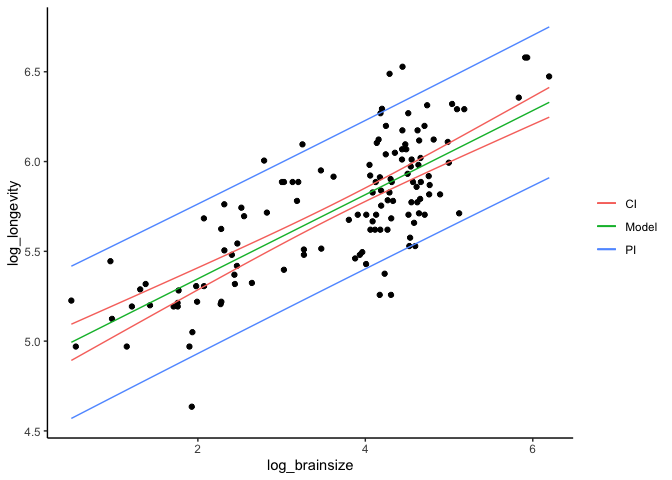

```r
plot2 <- ggplot(data = df2, aes(x = log_brainsize, y = log_longevity)) +
  geom_point() +
  geom_text(x=300, y=300, label="y = 0.2341x + 4.8790") +
  theme_classic() +
  geom_line(aes(x = log_brainsize, y = CIfit, color="Model")) +
  geom_line(aes(x = log_brainsize, y = CIlwr, color="CI")) +
  geom_line(aes(x = log_brainsize, y = CIupr, color="CI")) +
  geom_line(aes(x = log_brainsize, y = PIlwr, color="PI")) +
  geom_line(aes(x = log_brainsize, y = PIupr, color="PI")) +
  theme(legend.title=element_blank())
plot2
```

## Prediction

Produce a point estimate and associated 90 percent PI for the longevity of a species whose brain weight is 800 gm. Do you trust the model to predict observations accurately for this value of the explanatory variable? Why or why not?

*Ritika’s comments: Oh gosh I though this was in years! Not months! So thank you for making me realize that. One suggestion here, I’m not super clear what the difference between longevity800 and pi800 are, maybe you can add some comments here distinguishing the two? Also instead of using values maybe you can same variables that store the values e.g. slope_800, intercept_800 instead of 1.218 and 248.952 so we know what they represent/how you got them–just a suggestion feel free to reject it!*

### longevity~brain size

```r
longevity800 <- 1.218*(800) + 248.952
longevity800
```

```
## [1] 1223.352
```

```r
pi800 <- predict(model1, newdata = data.frame(brainsize = 800), interval = "prediction", level = 0.90)
pi800
```

```
##        fit      lwr      upr
## 1 1223.345 1021.805 1424.884
```

The predicted longevity is 1223.352 months (~101 years) with a prediction interval of 1021.805 to 1424.884. I do not think the model can predict very accurately for an 800g average brain size because this is pretty far from most of the data. Most species have a brain size below 200g.

### log(longevity)~log(brain size)

```r
log(800)
```

```
## [1] 6.684612
```

```r
log_longevity800 <- exp(0.2341 * log(800) + 4.8790)
log_longevity800
```

```
## [1] 628.8342
```

```r
log_pi800 <- exp(predict(model2, newdata = data.frame(log_brainsize = log(800)), interval = "prediction", level = 0.90))
log_pi800
```

```
##        fit      lwr      upr
## 1 629.0118 412.1652 959.9446
```

## Model Comparison

Looking at your two models, which do you think is better? Why?

*Ritika’s comments: This is a really great explanation! I looked at things more visually but I think this is a better explanation*

I think the log model is more appropriate for for this data. The F statistic for this model is 172.9 which is higher than the F statistic for the untransformed model which is 122.4. I’m not sure, but I think this means that the residuals are relatively smaller for the log model than the untransformed model and therefore the linear model fits the data more closely. The F statistic is a better comparison than the r-squared value because it is a formal test of whether the models differ from there being no relationship.

*Ritika’s comments: Great job Brooke! I think you killed this assignment!*

# Challenges I Faced

1. I was having a hard time figuring out what was wrong with my function when it seemed to run without an error but only produced 0s in the output. I realized that I needed the else(){} function to complement the first if(){} so that it would know what to do if the conditions of the if where not met. Understanding syntax in general was a challenge.
2. I am still unsure if I have set the function to correctly calculate confidence interval or follow the rule of thumb to produce a warning for the two sample tests.
3. It took me a while to figure out how to add a legend to the scatterplots because I had set the color of each line manually. When I figured out that I could set the color to a character variable, I learned that ggplot would produce a legend automatically.